# 10_minutes_to_pandas

```python
#Apply
#DataFrame.apply() applies a user defined function to the data
'''
o código df.apply(np.cumsum) retorna um novo DataFrame com a mesma estrutura do DataFrame original df,
onde cada valor é substituído pela soma cumulativa dos valores da coluna até aquela linha.
'''
df.apply(np.cumsum)
```

|  | A | B | C | D | F |
| --- | --- | --- | --- | --- | --- |
| 2013-01-01 | 0.000000 | 0.000000 | 0.732229 | 5 | NaN |
| 2013-01-02 | 1.529596 | -0.637405 | 1.073911 | 10 | 1.0 |
| 2013-01-03 | 0.704203 | -1.553244 | 0.824679 | 15 | 3.0 |
| 2013-01-04 | -0.078334 | -2.959282 | 2.411497 | 20 | 6.0 |
| 2013-01-05 | 0.380589 | -3.344770 | 2.896020 | 25 | 10.0 |
| 2013-01-06 | 0.632603 | -1.780502 | 3.135374 | 30 | 15.0 |

```python
'''
A função apply() é usada para aplicar uma função ao longo de um eixo do DataFrame
A função lambda lambda x: x.max() - x.min() é definida para calcular a diferença entre o valor máximo
(x.max()) e o valor mínimo (x.min()) de cada coluna. O argumento x representa cada coluna do DataFrame
'''

df.apply(lambda x:x.max() - x.min())
```

```
A    2.354988
B    2.970306
C    1.836050
D    0.000000
F    4.000000
dtype: float64
```

```python
#Histogramming

s= pd.Series(np.random.randint(0,7, size = 10))
print(s)

s.value_counts()
```

```
0    4
1    2
2    4
3    3
4    0
5    4
6    1
7    3
8    4
9    5
dtype: int32
```

```
4    4
3    2
2    1
0    1
1    1
5    1
dtype: int64
```

```python
# String methods
s = pd.Series(["A", "B", "C", "Aaba", "Baca", np.nan, "CABA", "dog", "cat"])
print(s)
s.str.lower()
```

```
0       A
1       B
2       C
3    Aaba
4    Baca
5     NaN
6    CABA
7     dog
8     cat
dtype: object
```

```
0       a
1       b
2       c
3    aaba
4    baca
5     NaN
6    caba
7     dog
8     cat
dtype: object
```

```python
#MERGE

#CONCACT

#Concatenating pandas objects together along an axis with concat():
df = pd.DataFrame(np.random.randn(10, 4))
df
```

|  | 0 | 1 | 2 | 3 |
| --- | --- | --- | --- | --- |
| 0 | -0.685893 | 0.622937 | -0.746593 | 2.261943 |
| 1 | 1.598966 | -0.107136 | 0.403588 | 0.387172 |
| 2 | 0.669598 | -2.158319 | -1.451921 | -0.595619 |
| 3 | 0.800965 | 0.890774 | -0.605896 | -0.231392 |
| 4 | 3.381177 | 1.273830 | -1.625987 | -0.649619 |
| 5 | -0.902104 | 2.135293 | 1.459900 | 1.096405 |
| 6 | -1.414015 | -0.620645 | -0.814061 | 1.087662 |
| 7 | -0.255726 | -1.362087 | -1.327317 | -1.277905 |
| 8 | -1.215344 | 0.432535 | 0.074421 | -0.163773 |
| 9 | 1.596344 | 0.976374 | -1.764571 | -0.554449 |

```python
# break it into pieces
pieces = [df[:3], df[3:7], df[7:]]
pieces
```

```
[          0         1         2         3
 0 -0.685893  0.622937 -0.746593  2.261943
 1  1.598966 -0.107136  0.403588  0.387172
 2  0.669598 -2.158319 -1.451921 -0.595619,
           0         1         2         3
 3  0.800965  0.890774 -0.605896 -0.231392
 4  3.381177  1.273830 -1.625987 -0.649619
 5 -0.902104  2.135293  1.459900  1.096405
 6 -1.414015 -0.620645 -0.814061  1.087662,
           0         1         2         3
 7 -0.255726 -1.362087 -1.327317 -1.277905
 8 -1.215344  0.432535  0.074421 -0.163773
 9  1.596344  0.976374 -1.764571 -0.554449]
```

```python
pd.concat(pieces)
```

|  | 0 | 1 | 2 | 3 |
| --- | --- | --- | --- | --- |
| 0 | -0.685893 | 0.622937 | -0.746593 | 2.261943 |
| 1 | 1.598966 | -0.107136 | 0.403588 | 0.387172 |
| 2 | 0.669598 | -2.158319 | -1.451921 | -0.595619 |
| 3 | 0.800965 | 0.890774 | -0.605896 | -0.231392 |
| 4 | 3.381177 | 1.273830 | -1.625987 | -0.649619 |
| 5 | -0.902104 | 2.135293 | 1.459900 | 1.096405 |
| 6 | -1.414015 | -0.620645 | -0.814061 | 1.087662 |
| 7 | -0.255726 | -1.362087 | -1.327317 | -1.277905 |
| 8 | -1.215344 | 0.432535 | 0.074421 | -0.163773 |
| 9 | 1.596344 | 0.976374 | -1.764571 | -0.554449 |

NOTA:

Adicionar uma coluna a um DataFrame é relativamente rápido. No entanto, adicionar uma linha requer uma cópia e pode ser caro. Recomendamos passar uma lista pré-criada de registros para o construtor DataFrame em vez de construir um DataFrame anexando iterativamente registros a ele.

```python
#JOIN
#merge()
left = pd.DataFrame({"key": ["foo", "foo"], "lval": [1, 2]})
left
```

|  | key | lval |
| --- | --- | --- |
| 0 | foo | 1 |
| 1 | foo | 2 |

```python
right = pd.DataFrame({"key": ["foo", "foo"], "rval": [4, 5]})
right
```

|  | key | rval |
| --- | --- | --- |
| 0 | foo | 4 |
| 1 | foo | 5 |

```python
pd.merge(left, right, on="key")
```

|  | key | lval | rval |
| --- | --- | --- | --- |
| 0 | foo | 1 | 4 |
| 1 | foo | 1 | 5 |
| 2 | foo | 2 | 4 |
| 3 | foo | 2 | 5 |

```python
#Another example that can be given is
left = pd.DataFrame({"key": ["foo", "bar"], "lval": [1, 2]})
right = pd.DataFrame({"key": ["foo", "bar"], "rval": [4, 5]})
```

```python
left
```

|  | key | lval |
| --- | --- | --- |
| 0 | foo | 1 |
| 1 | bar | 2 |

```python
right
```

|  | key | rval |
| --- | --- | --- |
| 0 | foo | 4 |
| 1 | bar | 5 |

```python
pd.merge(left, right, on="key")
```

|  | key | lval | rval |
| --- | --- | --- | --- |
| 0 | foo | 1 | 4 |
| 1 | bar | 2 | 5 |

Grouping

By “group by” we are referring to a process involving one or more of the following steps:

Splitting the data into groups based on some criteria

Applying a function to each group independently

Combining the results into a data structure

```python
#See the Grouping section.
df = pd.DataFrame(
    {
        "A": ["foo", "bar", "foo", "bar", "foo", "bar", "foo", "foo"],
        "B": ["one", "one", "two", "three", "two", "two", "one", "three"],
        "C": np.random.randn(8),
        "D": np.random.randn(8),
    }
)
df
```

|  | A | B | C | D |
| --- | --- | --- | --- | --- |
| 0 | foo | one | -0.142959 | 0.658949 |
| 1 | bar | one | -1.203623 | -0.241155 |
| 2 | foo | two | 1.167707 | -0.979008 |
| 3 | bar | three | -0.677701 | 0.837293 |
| 4 | foo | two | -1.215745 | -0.834056 |
| 5 | bar | two | 0.117280 | 0.199011 |
| 6 | foo | one | 0.430098 | 0.499112 |
| 7 | foo | three | 1.034453 | 2.918630 |

```python
#Grouping and then applying the sum() function to the resulting groups:
df.groupby("A")[["C", "D"]].sum()
```

| A | C | D |
| --- | --- | --- |
| bar | -1.764044 | 0.795148 |
| foo | 1.273554 | 2.263627 |

```python
#Grouping by multiple columns forms a hierarchical index, and again we can apply the sum() function:
df.groupby(["A", "B"]).sum()
```

| A | B | C | D |
| --- | --- | --- | --- |
| bar | one | -1.203623 | -0.241155 |
|  | three | -0.677701 | 0.837293 |
|  | two | 0.117280 | 0.199011 |
| foo | one | 0.287138 | 1.158061 |
|  | three | 1.034453 | 2.918630 |
|  | two | -0.048038 | -1.813064 |

```python
#Reshaping

#STACK
tuples = list(
    zip(
        ["bar", "bar", "baz", "baz", "foo", "foo", "qux", "qux"],
        ["one", "two", "one", "two", "one", "two", "one", "two"],
    )
)

tuples
```

```
[('bar', 'one'),
 ('bar', 'two'),
 ('baz', 'one'),
 ('baz', 'two'),
 ('foo', 'one'),
 ('foo', 'two'),
 ('qux', 'one'),
 ('qux', 'two')]
```

```python
index = pd.MultiIndex.from_tuples(tuples, names=["first", "second"])
index
```

```
MultiIndex([('bar', 'one'),
            ('bar', 'two'),
            ('baz', 'one'),
            ('baz', 'two'),
            ('foo', 'one'),
            ('foo', 'two'),
            ('qux', 'one'),
            ('qux', 'two')],
           names=['first', 'second'])
```

```python
df = pd.DataFrame(np.random.randn(8, 2), index=index, columns=["A", "B"])
df
```

| first | second | A | B |
| --- | --- | --- | --- |
| bar | one | 1.119280 | 0.369989 |
|  | two | 0.075262 | 1.069946 |
| baz | one | -0.682751 | 0.980104 |
|  | two | -0.772830 | 0.323390 |
| foo | one | 0.993127 | 0.314829 |
|  | two | -0.172721 | 0.545301 |
| qux | one | -1.396405 | 2.836924 |
|  | two | 1.191938 | -0.267835 |

```python
df2 = df[:4]
df2
```

| first | second | A | B |
| --- | --- | --- | --- |
| bar | one | 1.119280 | 0.369989 |
|  | two | 0.075262 | 1.069946 |
| baz | one | -0.682751 | 0.980104 |
|  | two | -0.772830 | 0.323390 |

```python
#The stack() method “compresses” a level in the DataFrame’s columns
stacked = df2.stack()
stacked
```

```
first  second
bar    one     A    1.119280
               B    0.369989
       two     A    0.075262
               B    1.069946
baz    one     A   -0.682751
               B    0.980104
       two     A   -0.772830
               B    0.323390
dtype: float64
```

```python
#With a “stacked” DataFrame or Series (having a MultiIndex as the index),
#the inverse operation of stack() is unstack(), which by default unstacks the last level:

stacked.unstack()
```

| first | second | A | B |
| --- | --- | --- | --- |
| bar | one | 1.119280 | 0.369989 |
|  | two | 0.075262 | 1.069946 |
| baz | one | -0.682751 | 0.980104 |
|  | two | -0.772830 | 0.323390 |

```python
stacked.unstack(1)
```

| first | second | one | two |
| --- | --- | --- | --- |
| bar | A | 1.119280 | 0.075262 |
|  | B | 0.369989 | 1.069946 |
| baz | A | -0.682751 | -0.772830 |
|  | B | 0.980104 | 0.323390 |

```python
stacked.unstack(0)
```

| second | first | bar | baz |
| --- | --- | --- | --- |
| one | A | 1.119280 | -0.682751 |
|  | B | 0.369989 | 0.980104 |
| two | A | 0.075262 | -0.772830 |
|  | B | 1.069946 | 0.323390 |

```python
#Pivot tables
#See the section on Pivot Tables.
df = pd.DataFrame(
    {
        "A": ["one", "one", "two", "three"] * 3,
        "B": ["A", "B", "C"] * 4,
        "C": ["foo", "foo", "foo", "bar", "bar", "bar"] * 2,
        "D": np.random.randn(12),
        "E": np.random.randn(12),
    }
)
df
```

|  | A | B | C | D | E |
| --- | --- | --- | --- | --- | --- |
| 0 | one | A | foo | -0.942348 | 2.063667 |
| 1 | one | B | foo | -0.629775 | -1.588598 |
| 2 | two | C | foo | -0.729090 | -1.065551 |
| 3 | three | A | bar | -0.378480 | -0.385558 |
| 4 | one | B | bar | 1.692816 | -1.058001 |
| 5 | one | C | bar | 0.133195 | 0.442925 |
| 6 | two | A | foo | -1.856905 | -0.418589 |
| 7 | three | B | foo | 1.992192 | 1.242995 |
| 8 | one | C | foo | -1.186892 | 1.017483 |
| 9 | one | A | bar | 1.358893 | 0.576722 |
| 10 | two | B | bar | 0.434195 | -2.131574 |
| 11 | three | C | bar | -0.015643 | 0.864858 |

```python
#pivot_table() pivots a DataFrame specifying the values, index and columns
pd.pivot_table(df, values="D", index=["A", "B"], columns=["C"])
```

| A | C B | bar | foo |
| --- | --- | --- | --- |
| one | A | 1.358893 | -0.942348 |
|  | B | 1.692816 | -0.629775 |
|  | C | 0.133195 | -1.186892 |
| three | A | -0.378480 | NaN |
|  | B | NaN | 1.992192 |
|  | C | -0.015643 | NaN |
| two | A | NaN | -1.856905 |
|  | B | 0.434195 | NaN |
|  | C | NaN | -0.729090 |

Time series

O pandas possui uma funcionalidade simples, poderosa e eficiente para realizar operações de reamostragem durante a conversão de frequência (por exemplo, converter dados secundários em dados de 5 minutos). Isso é extremamente comum, mas não limitado a, aplicações financeiras

```python
'''
Esse código cria uma sequência de datas e horários usando a biblioteca pandas em Python.
Ele gera um objeto do tipo DatetimeIndex com 100 elementos, representando intervalos de um segundo (freq="S")
a partir de 1º de janeiro de 2012.
Essa sequência pode ser usada para indexar e manipular dados temporais em uma análise de séries temporais.
'''
rng = pd.date_range("1/1/2012", periods=100, freq="S")
rng
```

```
DatetimeIndex(['2012-01-01 00:00:00', '2012-01-01 00:00:01',
               '2012-01-01 00:00:02', '2012-01-01 00:00:03',
               '2012-01-01 00:00:04', '2012-01-01 00:00:05',
               '2012-01-01 00:00:06', '2012-01-01 00:00:07',
               '2012-01-01 00:00:08', '2012-01-01 00:00:09',
               '2012-01-01 00:00:10', '2012-01-01 00:00:11',
               '2012-01-01 00:00:12', '2012-01-01 00:00:13',
               '2012-01-01 00:00:14', '2012-01-01 00:00:15',
               '2012-01-01 00:00:16', '2012-01-01 00:00:17',
               '2012-01-01 00:00:18', '2012-01-01 00:00:19',
               '2012-01-01 00:00:20', '2012-01-01 00:00:21',
               '2012-01-01 00:00:22', '2012-01-01 00:00:23',
               '2012-01-01 00:00:24', '2012-01-01 00:00:25',
               '2012-01-01 00:00:26', '2012-01-01 00:00:27',
               '2012-01-01 00:00:28', '2012-01-01 00:00:29',
               '2012-01-01 00:00:30', '2012-01-01 00:00:31',
               '2012-01-01 00:00:32', '2012-01-01 00:00:33',
               '2012-01-01 00:00:34', '2012-01-01 00:00:35',
               '2012-01-01 00:00:36', '2012-01-01 00:00:37',
               '2012-01-01 00:00:38', '2012-01-01 00:00:39',
               '2012-01-01 00:00:40', '2012-01-01 00:00:41',
               '2012-01-01 00:00:42', '2012-01-01 00:00:43',
               '2012-01-01 00:00:44', '2012-01-01 00:00:45',
               '2012-01-01 00:00:46', '2012-01-01 00:00:47',
               '2012-01-01 00:00:48', '2012-01-01 00:00:49',
               '2012-01-01 00:00:50', '2012-01-01 00:00:51',
               '2012-01-01 00:00:52', '2012-01-01 00:00:53',
               '2012-01-01 00:00:54', '2012-01-01 00:00:55',
               '2012-01-01 00:00:56', '2012-01-01 00:00:57',
               '2012-01-01 00:00:58', '2012-01-01 00:00:59',
               '2012-01-01 00:01:00', '2012-01-01 00:01:01',
               '2012-01-01 00:01:02', '2012-01-01 00:01:03',
               '2012-01-01 00:01:04', '2012-01-01 00:01:05',
               '2012-01-01 00:01:06', '2012-01-01 00:01:07',
               '2012-01-01 00:01:08', '2012-01-01 00:01:09',
               '2012-01-01 00:01:10', '2012-01-01 00:01:11',
               '2012-01-01 00:01:12', '2012-01-01 00:01:13',
               '2012-01-01 00:01:14', '2012-01-01 00:01:15',
               '2012-01-01 00:01:16', '2012-01-01 00:01:17',
               '2012-01-01 00:01:18', '2012-01-01 00:01:19',
               '2012-01-01 00:01:20', '2012-01-01 00:01:21',
               '2012-01-01 00:01:22', '2012-01-01 00:01:23',
               '2012-01-01 00:01:24', '2012-01-01 00:01:25',
               '2012-01-01 00:01:26', '2012-01-01 00:01:27',
               '2012-01-01 00:01:28', '2012-01-01 00:01:29',
               '2012-01-01 00:01:30', '2012-01-01 00:01:31',
               '2012-01-01 00:01:32', '2012-01-01 00:01:33',
               '2012-01-01 00:01:34', '2012-01-01 00:01:35',
               '2012-01-01 00:01:36', '2012-01-01 00:01:37',
               '2012-01-01 00:01:38', '2012-01-01 00:01:39'],
              dtype='datetime64[ns]', freq='S')
```

```python
'''
Esse código cria uma série temporal chamada ts usando a biblioteca pandas em Python.
A série é gerada com valores aleatórios inteiros entre 0 e 500, com o mesmo comprimento da sequência de datas
rng criada anteriormente. Os valores aleatórios são indexados pelas datas e horários da sequência rng.
Essa série pode ser usada para realizar análises e visualizações de dados temporais
'''
ts = pd.Series(np.random.randint(0, 500, len(rng)), index=rng)
ts
```

```
2012-01-01 00:00:00    478
2012-01-01 00:00:01    310
2012-01-01 00:00:02    392
2012-01-01 00:00:03    427
2012-01-01 00:00:04     74
                      ...
2012-01-01 00:01:35    425
2012-01-01 00:01:36     39
2012-01-01 00:01:37    295
2012-01-01 00:01:38     36
2012-01-01 00:01:39    351
Freq: S, Length: 100, dtype: int32
```

```python
'''
realiza uma operação de agregação na série temporal ts.
A função resample é usada para agrupar os valores da série em intervalos de 5 minutos.
A seguir, a função sum é aplicada a cada grupo, resultando na soma dos valores dentro de cada intervalo de 5 minutos.
O resultado é uma nova série temporal que representa a soma dos valores em intervalos de 5 minutos.
Essa técnica é útil para obter uma visão resumida dos dados temporais em um intervalo de tempo específico.
'''
ts.resample("5Min").sum()
```

```
2012-01-01    22885
Freq: 5T, dtype: int32
```

```python
#Series.tz_localize() localizes a time series to a time zone:
rng = pd.date_range("3/6/2012 00:00", periods=5, freq="D")
rng
```

```
DatetimeIndex(['2012-03-06', '2012-03-07', '2012-03-08', '2012-03-09',
               '2012-03-10'],
              dtype='datetime64[ns]', freq='D')
```

```python
ts = pd.Series(np.random.randn(len(rng)), rng)
ts
```

```
2012-03-06    0.654354
2012-03-07   -0.615780
2012-03-08    0.215663
2012-03-09   -0.724351
2012-03-10    1.049724
Freq: D, dtype: float64
```

```python
ts_utc = ts.tz_localize("UTC")
ts_utc
```

```
2012-03-06 00:00:00+00:00    0.654354
2012-03-07 00:00:00+00:00   -0.615780
2012-03-08 00:00:00+00:00    0.215663
2012-03-09 00:00:00+00:00   -0.724351
2012-03-10 00:00:00+00:00    1.049724
Freq: D, dtype: float64
```

```python
#Series.tz_convert() converts a timezones aware time series to another time zone:
ts_utc.tz_convert("US/Eastern")
```

```
2012-03-05 19:00:00-05:00    0.654354
2012-03-06 19:00:00-05:00   -0.615780
2012-03-07 19:00:00-05:00    0.215663
2012-03-08 19:00:00-05:00   -0.724351
2012-03-09 19:00:00-05:00    1.049724
Freq: D, dtype: float64
```

```python
#Converting between time span representations:
rng = pd.date_range("1/1/2012", periods=5, freq="M")
ts = pd.Series(np.random.randn(len(rng)), index=rng)
ts
```

```
2012-01-31    0.971906
2012-02-29    1.839600
2012-03-31   -0.634024
2012-04-30    0.062843
2012-05-31   -0.702796
Freq: M, dtype: float64
```

```python
'''
Esse código converte a série temporal ts em uma nova série temporal chamada ps,
onde os índices são representados por períodos em vez de datas e horários.
A função to_period() é usada para realizar essa conversão, transformando os valores de data e hora em períodos,
como meses, trimestres, anos, etc. Isso pode ser útil quando se deseja agrupar e analisar os dados por
períodos específicos em vez de por datas e horários individuais
'''
ps = ts.to_period()
ps
```

```
2012-01    0.971906
2012-02    1.839600
2012-03   -0.634024
2012-04    0.062843
2012-05   -0.702796
Freq: M, dtype: float64
```

```python
ps.to_timestamp()
```

```
2012-01-01    0.971906
2012-02-01    1.839600
2012-03-01   -0.634024
2012-04-01    0.062843
2012-05-01   -0.702796
Freq: MS, dtype: float64
```

A conversão entre período e timestamp permite que algumas funções aritméticas convenientes sejam usadas. No exemplo a seguir, convertemos uma frequência trimestral com ano finalizado em novembro às 9h do final do mês seguinte ao final do trimestre

```python
prng = pd.period_range("1990Q1", "2000Q4", freq="Q-NOV")
ts = pd.Series(np.random.randn(len(prng)), prng)
ts.index = (prng.asfreq("M", "e") + 1).asfreq("H", "s") + 9
ts.head()
```

```
1990-03-01 09:00    0.310875
1990-06-01 09:00    0.127261
1990-09-01 09:00   -0.641117
1990-12-01 09:00    0.619419
1991-03-01 09:00    1.287257
Freq: H, dtype: float64
```

Categoricals

pandas can include categorical data in a DataFrame.

```python
df = pd.DataFrame(
    {"id": [1, 2, 3, 4, 5, 6], "raw_grade": ["a", "b", "b", "a", "a", "e"]}
)
df
```

|  | id | raw_grade |
| --- | --- | --- |
| 0 | 1 | a |
| 1 | 2 | b |
| 2 | 3 | b |
| 3 | 4 | a |
| 4 | 5 | a |
| 5 | 6 | e |

```python
#Converting the raw grades to a categorical data type:
'''
Esse código adiciona uma nova coluna chamada "grade" ao DataFrame df.
A nova coluna é criada a partir da coluna existente chamada "raw_grade".
A função astype("category") é usada para converter os valores da coluna "raw_grade" em uma categoria.
A categoria é uma forma de representar dados categóricos, onde cada valor único é tratado como uma categoria distinta.
Essa conversão pode ser útil para análises estatísticas ou visualizações que envolvem dados categóricos.
'''
df["grade"] = df["raw_grade"].astype("category")

df["grade"]
```

```
0    a
1    b
2    b
3    a
4    a
5    e
Name: grade, dtype: category
Categories (3, object): ['a', 'b', 'e']
```

```python
#Rename the categories to more meaningful names:
new_categories = ["very good", "good", "very bad"]

df["grade"] = df["grade"].cat.rename_categories(new_categories)
df
```

|  | id | raw_grade | grade |
| --- | --- | --- | --- |
| 0 | 1 | a | very good |
| 1 | 2 | b | good |
| 2 | 3 | b | good |
| 3 | 4 | a | very good |
| 4 | 5 | a | very good |
| 5 | 6 | e | very bad |

```python
#Reorder the categories and simultaneously add the missing categories (methods under Series.cat()
#return a new Series by default):
df["grade"] = df["grade"].cat.set_categories(
    ["very bad", "bad", "medium", "good", "very good"]
)


df["grade"]
```

```
0    very good
1         good
2         good
3    very good
4    very good
5     very bad
Name: grade, dtype: category
Categories (5, object): ['very bad', 'bad', 'medium', 'good', 'very good']
```

```python
df
```

|  | id | raw_grade | grade |
| --- | --- | --- | --- |
| 0 | 1 | a | very good |
| 1 | 2 | b | good |
| 2 | 3 | b | good |
| 3 | 4 | a | very good |
| 4 | 5 | a | very good |
| 5 | 6 | e | very bad |

```python
#Sorting is per order in the categories, not lexical order
df.sort_values(by="grade")
```

|  | id | raw_grade | grade |
| --- | --- | --- | --- |
| 5 | 6 | e | very bad |
| 1 | 2 | b | good |
| 2 | 3 | b | good |
| 0 | 1 | a | very good |
| 3 | 4 | a | very good |
| 4 | 5 | a | very good |

```python
#Grouping by a categorical column also shows empty categories
df.groupby("grade").size()
```

```
grade
very bad     1
bad          0
medium       0
good         2
very good    3
dtype: int64
```

```python
#Plotting
import matplotlib.pyplot as plt
# %matplotlib inline é usado para permitir que os gráficos do Matplotlib sejam exibidos
#diretamente no notebook Jupyter, em vez de em uma janela separada
%matplotlib inline
'''
Esse código fecha todas as figuras de plotagem abertas no matplotlib. A função plt.close("all")
é usada para fechar todas as janelas de plotagem que estão atualmente abertas.
Isso pode ser útil quando você deseja limpar a área de trabalho e começar com uma nova visualização ou gráfico.
'''
plt.close("all")
```

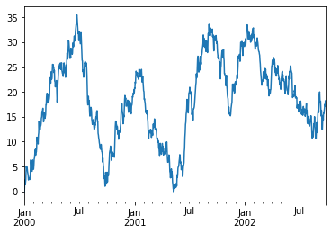

```python
ts = pd.Series(np.random.randn(1000), index=pd.date_range("1/1/2000", periods=1000))

ts = ts.cumsum()

ts.plot();
```

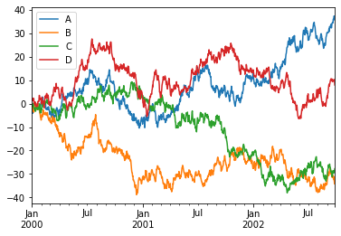

```python
#On a DataFrame, the plot() method is a convenience to plot all of the columns with labels:
df = pd.DataFrame(
    np.random.randn(1000, 4), index=ts.index, columns=["A", "B", "C", "D"]
)


df = df.cumsum()

plt.figure();

df.plot();

plt.legend(loc='best');
```

Importing and exporting data

CSV

```python
#Writing to a csv file: using DataFrame.to_csv()
df.to_csv("foo.csv")
```

```python
#Reading from a csv file: using read_csv()
pd.read_csv("foo.csv")
```

|  | Unnamed: 0 | A | B | C | D |
| --- | --- | --- | --- | --- | --- |
| 0 | 2000-01-01 | -1.402535 | -1.378104 | -0.749337 | 1.268572 |
| 1 | 2000-01-02 | -3.347671 | -1.943453 | -1.043986 | 1.401334 |
| 2 | 2000-01-03 | -4.154709 | -1.162935 | -0.764172 | 1.650694 |
| 3 | 2000-01-04 | -3.080220 | -0.908571 | -0.533067 | 2.352152 |
| 4 | 2000-01-05 | -1.989871 | -2.602976 | 0.135215 | 2.117063 |
| ... | ... | ... | ... | ... | ... |
| 995 | 2002-09-22 | 36.221175 | -32.392267 | -29.665757 | 9.730195 |
| 996 | 2002-09-23 | 36.378797 | -31.107388 | -28.959116 | 9.811929 |
| 997 | 2002-09-24 | 37.413301 | -32.526094 | -28.816295 | 10.307662 |
| 998 | 2002-09-25 | 35.736246 | -34.244929 | -28.894798 | 9.782765 |
| 999 | 2002-09-26 | 36.609145 | -34.089814 | -27.757022 | 7.957422 |

1000 rows × 5 columns

HDF5

Um arquivo HDF5 (Hierarchical Data Format 5) é um formato de arquivo de dados binários usado para armazenar grandes volumes de dados de forma eficiente. O HDF5 é um formato flexível, portátil e extensível que permite organizar, armazenar e gerenciar uma variedade de tipos de dados, incluindo conjuntos de dados multidimensionais, estruturas hierárquicas e metadados.

O formato HDF5 é amplamente utilizado em áreas que exigem armazenamento eficiente de dados científicos, como física, astronomia, bioinformática, finanças e ciência dos materiais. Ele é capaz de lidar com grandes conjuntos de dados e oferece suporte a recursos como compressão, filtragem, armazenamento de metadados detalhados e acesso eficiente a dados através de índices.

Um arquivo HDF5 pode conter vários conjuntos de dados, chamados de grupos, organizados em uma estrutura de árvore hierárquica semelhante a um sistema de arquivos. Cada grupo pode conter datasets (conjuntos de dados) que armazenam os próprios dados. Os datasets podem ser multidimensionais, como arrays, ou unidimensionais, como séries temporais.

O formato HDF5 também suporta atributos, que são metadados associados a grupos e datasets. Os atributos podem conter informações adicionais sobre os dados, como unidades, descrições, autores, entre outros.

Os arquivos HDF5 podem ser acessados e manipulados usando bibliotecas em várias linguagens de programação, incluindo Python, MATLAB, Java e C/C++. No contexto do pandas em Python, a biblioteca pytables é usada para trabalhar com arquivos HDF5

Reading and writing to HDFStores.

**instalar pacote pytables**

**conda install -c conda-forge pytables**

```python
#Writing to a HDF5 Store using DataFrame.to_hdf():
df.to_hdf("foo.h5", "df")
```

```python
#Reading from a HDF5 Store using read_hdf():
pd.read_hdf("foo.h5", "df")
```

|  | A | B | C | D |
| --- | --- | --- | --- | --- |
| 2000-01-01 | -1.402535 | -1.378104 | -0.749337 | 1.268572 |
| 2000-01-02 | -3.347671 | -1.943453 | -1.043986 | 1.401334 |
| 2000-01-03 | -4.154709 | -1.162935 | -0.764172 | 1.650694 |
| 2000-01-04 | -3.080220 | -0.908571 | -0.533067 | 2.352152 |
| 2000-01-05 | -1.989871 | -2.602976 | 0.135215 | 2.117063 |
| ... | ... | ... | ... | ... |
| 2002-09-22 | 36.221175 | -32.392267 | -29.665757 | 9.730195 |
| 2002-09-23 | 36.378797 | -31.107388 | -28.959116 | 9.811929 |
| 2002-09-24 | 37.413301 | -32.526094 | -28.816295 | 10.307662 |
| 2002-09-25 | 35.736246 | -34.244929 | -28.894798 | 9.782765 |
| 2002-09-26 | 36.609145 | -34.089814 | -27.757022 | 7.957422 |

1000 rows × 4 columns

Excel

Reading and writing to Excel.

```python
#Writing to an excel file using DataFrame.to_excel():
import openpyxl
df.to_excel("foo.xlsx", sheet_name="Sheet1")
```

```python
#Reading from an excel file using read_excel():
pd.read_excel("foo.xlsx", "Sheet1", index_col=None, na_values=["NA"])
```

|  | Unnamed: 0 | A | B | C | D |
| --- | --- | --- | --- | --- | --- |
| 0 | 2000-01-01 | -1.402535 | -1.378104 | -0.749337 | 1.268572 |
| 1 | 2000-01-02 | -3.347671 | -1.943453 | -1.043986 | 1.401334 |
| 2 | 2000-01-03 | -4.154709 | -1.162935 | -0.764172 | 1.650694 |
| 3 | 2000-01-04 | -3.080220 | -0.908571 | -0.533067 | 2.352152 |
| 4 | 2000-01-05 | -1.989871 | -2.602976 | 0.135215 | 2.117063 |
| ... | ... | ... | ... | ... | ... |
| 995 | 2002-09-22 | 36.221175 | -32.392267 | -29.665757 | 9.730195 |
| 996 | 2002-09-23 | 36.378797 | -31.107388 | -28.959116 | 9.811929 |
| 997 | 2002-09-24 | 37.413301 | -32.526094 | -28.816295 | 10.307662 |
| 998 | 2002-09-25 | 35.736246 | -34.244929 | -28.894798 | 9.782765 |
| 999 | 2002-09-26 | 36.609145 | -34.089814 | -27.757022 | 7.957422 |

1000 rows × 5 columns

Gotchas

```python
if pd.Series([False, True, False]):
     print("I was true")
```

```
Traceback (most recent call last):

  Cell In[101], line 1
    if pd.Series([False, True, False]):

  File ~\anaconda3\envs\mlearn\lib\site-packages\pandas\core\generic.py:1527 in __nonzero__
    raise ValueError(

ValueError: The truth value of a Series is ambiguous. Use a.empty, a.bool(), a.item(), a.any() or a.all().
```